# Japan Influenza Trends 2024-2025: A Data Analysis

## Data

The data for this project was gathered primarily from the Japan Institute for Health Security, the CDC, 'The Infectious Disease Website' of Japan, as well as the World Health Organization. The collected data includes much of the 2024-2025 influenza season with: reports by age and sex, deaths by age, hospitalizations by age, detection of types of viruses, detection by prefecture, and detection by virus with drug resistance. Data was scraped and cleaned in Excel prior to import.

```python
import pandas as pd
import matplotlib.pyplot as plt
import sys
import seaborn as sns
import numpy as np

# Load workbook
xls = pd.ExcelFile('Japan_Influenza_2425.xlsx')
sheet_names = xls.sheet_names
dfs = {sheet: xls.parse(sheet) for sheet in sheet_names}

print(dfs.keys())
```

```
dict_keys(['Detection_AV_DR_Inf_2425', 'Detection_H1N1_mH275Y_byp_2425', 'Situation_Updates_2425', 'Detections_by_Subtype_2425', 'Detection_H1N1_mH275Y_byw_2425', 'ReportedByAge', 'HospByAge', 'Deaths by Age'])
```

```python
# Assign Each Sheet to its own variable for easy DataFrame use
detectresist_df = dfs['Detection_AV_DR_Inf_2425']
detectprefect_df = dfs['Detection_H1N1_mH275Y_byp_2425']
situation_df = dfs['Situation_Updates_2425']
detectsubtype_df = dfs['Detections_by_Subtype_2425']
detectweek_df = dfs['Detection_H1N1_mH275Y_byw_2425']
cases_df = dfs['ReportedByAge']
hosp_df = dfs['HospByAge']
death_df = dfs['Deaths by Age']

# Data Overview
for name, df in dfs.items():
    print(f"\n=== {name} ===")
    print(f"Rows: {len(df)}, Columns: {list(df.columns)}")
```

```
=== Detection_AV_DR_Inf_2425 ===
Rows: 18, Columns: ['Virus Type', 'Drug', 'Viruses Tested', 'Resistant (n)', 'Resistant (%)', 'Total Viruses Reported']

=== Detection_H1N1_mH275Y_byp_2425 ===
Rows: 46, Columns: ['Prefecture', 'Number of Viruses Tested', 'Number of H275Y Mutant Viruses', 'Number of 275H/Y Mixed Populations']

=== Situation_Updates_2425 ===
Rows: 16, Columns: ['Report Week', 'Date', 'cum_positive_specimen', 'quant_change', 'avg_change_by_week', 'percent_change', 'avg_percent_change_by_week']

=== Detections_by_Subtype_2425 ===
Rows: 52, Columns: ['Country area or territory', 'Surveillance site type', 'Year-week (ISO 8601 calendar)', 'Week start date (ISO 8601 calendar)', 'Specimen tested', 'Influenza positive', 'Influenza negative', 'A (H1)', 'A (H1N1)pdm09', 'A (H3)', 'A (H5)', 'A not subtyped', 'B (Victoria)', 'B (Yamag…

=== Detection_H1N1_mH275Y_byw_2425 ===
Rows: 37, Columns: ['Sampling Week', 'Sampling Date', 'Number of Viruses Tested', 'Number of H275Y Mutant Viruses', 'Number of 275H/Y Mixed Populations']

=== ReportedByAge ===
Rows: 1480, Columns: ['Year-week ', 'Week start date ', 'Label', 'Start Age (years)', 'End Age (years)', 'Sex', 'Count']

=== HospByAge ===
Rows: 370, Columns: ['Year-week ', 'Week start date ', 'Start Age', 'End Age', 'Hospitilizations']

=== Deaths by Age ===
Rows: 407, Columns: ['Year-week ', 'Week start date ', 'Start Age', 'End Age', 'Deaths']
```

## Analysis

### Descriptive Statistics

```
Total influenza cases (overall): 1,356,743
```

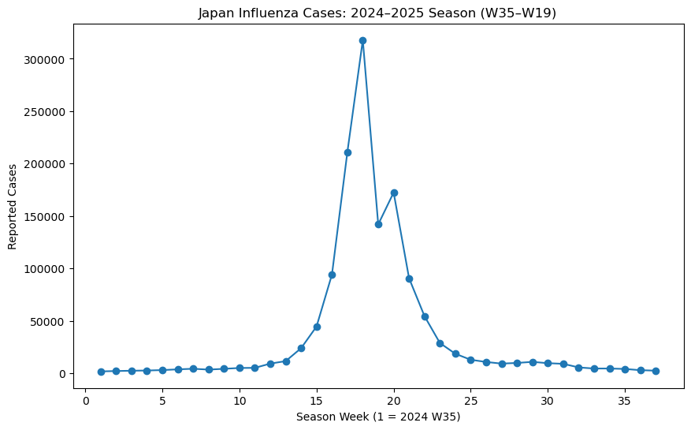

[output not shown]

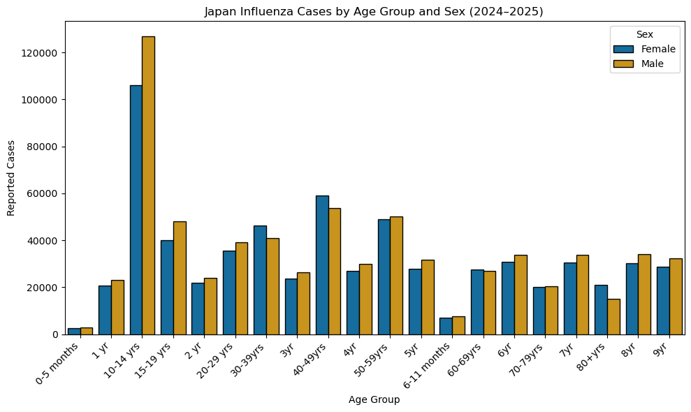

```
Overall peak group: 10-14 yrs (Male) with 127,003 cases.
Peak week per age group × sex (sorted by peak size):
```

|  | Label | Sex | Peak_SeasonWeek | Peak_Count |
| --- | --- | --- | --- | --- |
| 202 | 10-14 yrs | Male | 18 | 29628 |
| 165 | 10-14 yrs | Female | 18 | 24873 |
| 609 | 40-49yrs | Female | 18 | 14910 |
| 646 | 40-49yrs | Male | 18 | 13370 |
| 794 | 50-59yrs | Male | 18 | 12615 |
| 757 | 50-59yrs | Female | 18 | 12072 |
| 461 | 30-39yrs | Female | 18 | 10809 |
| 276 | 15-19 yrs | Male | 18 | 10758 |
| 498 | 30-39yrs | Male | 18 | 9591 |
| 239 | 15-19 yrs | Female | 18 | 9424 |
| 424 | 20-29 yrs | Male | 18 | 8755 |
| 1386 | 8yr | Male | 18 | 8324 |
| 1238 | 7yr | Male | 18 | 8184 |
| 387 | 20-29 yrs | Female | 18 | 8079 |
| 1460 | 9yr | Male | 18 | 8015 |

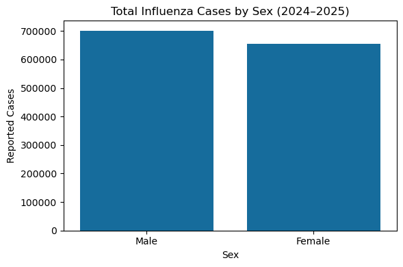

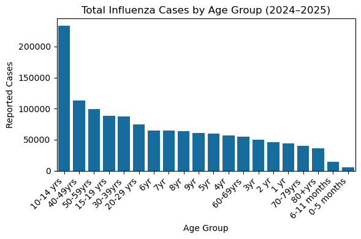

```
Peak age group: 10-14 yrs with 233,192 total reported cases.
Peak sex: Male with 700,844 total reported cases.
```

```python
# -- Total Influenza Cases --
total_cases = cases_df['Count'].sum()
print(f"Total influenza cases (overall): {total_cases:,}")

# -- Cases Seasonally --
## Each record in the dataset represents influenza reports aggregated weekly. Because the time format follows a `YYYY-WW` structure, I extracted the year and week values for temporal analysis.
cases_df[['Year', 'Week']] = cases_df['Year-week '].astype(str).str.split('-', expand=True)
cases_df['Year'] = cases_df['Year'].astype(int)
cases_df['Week'] = cases_df['Week'].astype(int)

## Combine year and Week into a single numeric order
### To align the 2024–2025 influenza season into a single continuous timeline, I reindexed calendar weeks into a new variable `SeasonWeek`. This vectorized approach uses pandas masks for performance and clarity, avoiding row-level iteration while preserving readability.
cases_df['SeasonWeek'] = pd.NA
mask_24 = cases_df['Year'] == 2024
mask_25 = cases_df['Year'] == 2025
cases_df.loc[mask_24, 'SeasonWeek'] = cases_df.loc[mask_24, 'Week'] - 34
cases_df.loc[mask_25, 'SeasonWeek'] = 18 + cases_df.loc[mask_25, 'Week']
cases_df['SeasonWeek'] = cases_df['SeasonWeek'].astype('Int64')

season = cases_df.dropna(subset=['SeasonWeek']).copy()
cases_by_season_week = season.groupby('SeasonWeek', as_index=False)['Count'].sum()

## Peak SeasonWeek
peak_row = cases_by_season_week.loc[cases_by_season_week['Count'].idxmax()]
peak_week = int(peak_row['SeasonWeek'])
peak_val = int(peak_row['Count'])

plt.figure(figsize=(10,6))
plt.plot(cases_by_season_week['SeasonWeek'], cases_by_season_week['Count'], marker='o')
plt.title('Japan Influenza Cases: 2024–2025 Season (W35–W19)')
plt.xlabel('Season Week (1 = 2024 W35)')
plt.ylabel('Reported Cases')
plt.show()

print(f"Peak influenza activity occurred in Season Week {peak_week} with {peak_val:,} reported cases.")

# -- Cases by Week --
cases_by_week = cases_df.groupby(['Year', 'Week'], as_index=False)['Count'].sum()

# -- Case Distribution --
mean_cases = cases_df['Count'].mean()
median_cases = cases_df['Count'].median()
std_cases = cases_df['Count'].std()

print(f"Average weekly cases: {mean_cases:,.0f}")
print(f"Median weekly cases: {median_cases:,.0f}")
print(f"Standard deviation (spread): {std_cases:,.0f}")

# -- Cases by Age & Sex --
cases_by_age_sex = cases_df.groupby(['Label', 'Sex'], as_index=False)['Count'].sum()

plt.figure(figsize=(10,6))
sns.barplot(data=cases_by_age_sex, x='Label', y='Count', hue='Sex', palette=['#0072B2', '#E69F00'], edgecolor='black')

plt.title('Japan Influenza Cases by Age Group and Sex (2024–2025)')
plt.xlabel('Age Group')
plt.ylabel('Reported Cases')
plt.xticks(rotation=45, ha='right')
plt.legend(title='Sex')
plt.tight_layout()
plt.show()

## Overall Peak Age Group x Sex
peak_overall = cases_by_age_sex.loc[cases_by_age_sex['Count'].idxmax()]
print(
    f"Overall peak group: {peak_overall['Label']} ({peak_overall['Sex']}) "
    f"with {int(peak_overall['Count']):,} cases.")

## Peak Week per Age Group x Sex
by_age_sex_week = (
    cases_df.dropna(subset=['SeasonWeek'])
            .groupby(['Label', 'Sex', 'SeasonWeek'], as_index=False)['Count']
            .sum())

idx = by_age_sex_week.groupby(['Label', 'Sex'])['Count'].idxmax()
peaks_by_age_sex = by_age_sex_week.loc[idx].sort_values('Count', ascending=False)

peaks_by_age_sex = peaks_by_age_sex.rename(
    columns={'SeasonWeek': 'Peak_SeasonWeek', 'Count': 'Peak_Count'})

print("Peak week per age group × sex (sorted by peak size):")
display(peaks_by_age_sex.head(15))

## Peak Sex
cases_by_sex = cases_df.groupby('Sex', as_index=False)['Count'].sum().sort_values('Count', ascending=False)
peak_sex = cases_by_sex.iloc[0]

plt.figure(figsize=(6,4))
sns.barplot(data=cases_by_sex, x='Sex', y='Count', color='#0072B2')
plt.title('Total Influenza Cases by Sex (2024–2025)')
plt.ylabel('Reported Cases')
plt.xlabel('Sex')
plt.tight_layout()
plt.show()

## Peak Age Group
cases_by_age = cases_df.groupby('Label', as_index=False)['Count'].sum().sort_values('Count', ascending=False)
peak_age = cases_by_age.iloc[0]

plt.figure(figsize=(6,4))
sns.barplot(data=cases_by_age, x='Label', y='Count', color='#0072B2')
plt.title('Total Influenza Cases by Age Group (2024–2025)')
plt.ylabel('Reported Cases')
plt.xlabel('Age Group')
plt.xticks(rotation=45, ha='right')
plt.tight_layout()
plt.show()

print(f"Peak age group: {peak_age['Label']} with {int(peak_age['Count']):,} total reported cases.")
print(f"Peak sex: {peak_sex['Sex']} with {int(peak_sex['Count']):,} total reported cases.")
```

### Trend Analysis

In the descriptive statistics section, we established the overall shape and timing of influenza activity for the 2024–2025 season using the unified `SeasonWeek` index.  
This section extends that analysis by examining how cases evolve week-to-week, identifying short-term momentum, and highlighting age-specific temporal patterns.

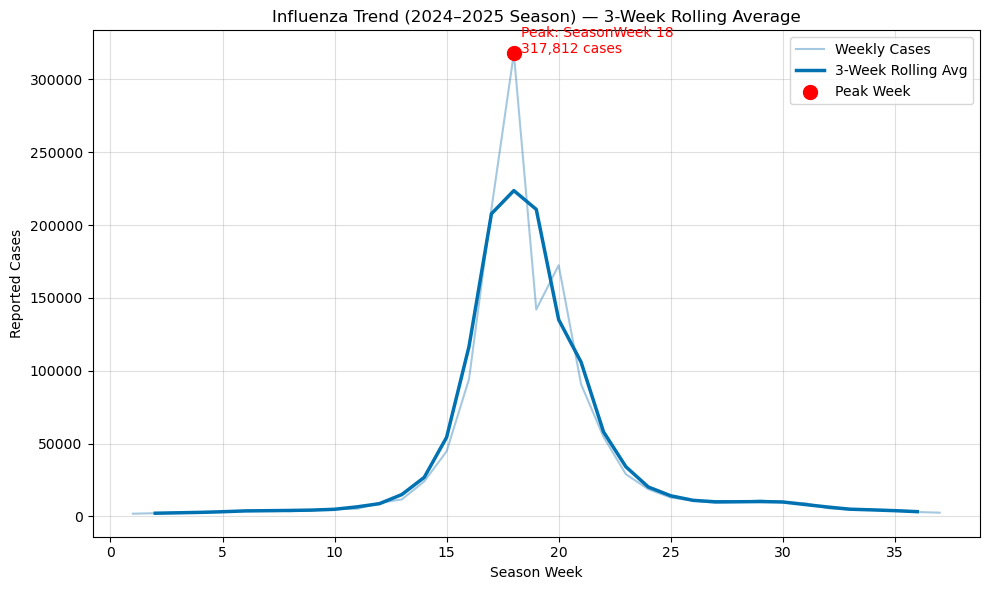

```
    The rolling-average curve smooths natural week-to-week noise and reveals the underlying trend.
    The seasonal peak occurred at SeasonWeek 18, which corresponds to ISO Week 52 of 2024 (late December).
    This aligns with expected influenza seasonality in Japan: a sharp early-winter surge followed by a slower decline through January.
```

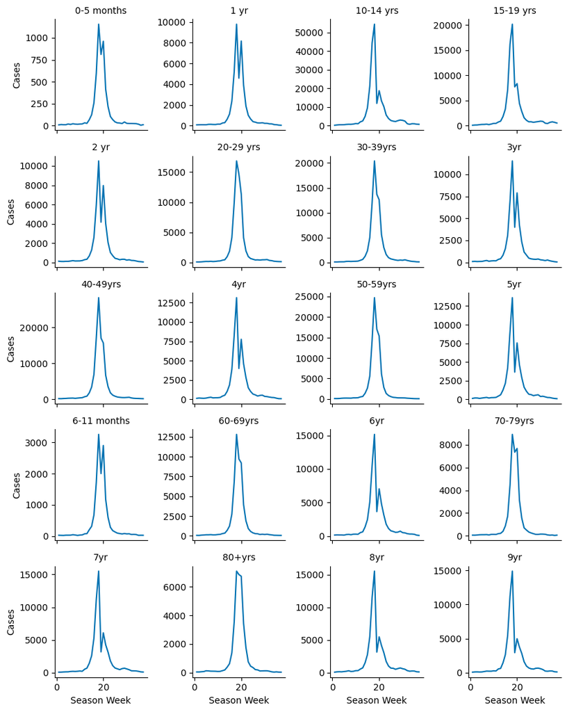

```
    To avoid overplotting 20 age groups on a single line chart, I visualized the 2024–2025 influenza season as a grid of small multiples (one panel per age group).
    Each subplot shows weekly case counts over `SeasonWeek`, starting at 2024 Week 35 and ending at 2025 Week 19.
    The age group with the highest peak is evidently the 10-14 year old range, which aligns with expectations for morbidity in school-aged children.
```

```python
# Data Prep
season_trend = cases_by_season_week.copy()
season_trend = season_trend.sort_values('SeasonWeek')

# 3-week Rolling Average
season_trend['Rolling3'] = season_trend['Count'].rolling(window=3, center=True).mean()

plt.figure(figsize=(10,6))
plt.plot(season_trend['SeasonWeek'], season_trend['Count'], alpha=0.4, label='Weekly Cases')
plt.plot(season_trend['SeasonWeek'], season_trend['Rolling3'], color='#0072B2', linewidth=2.5, label='3-Week Rolling Avg')

plt.scatter(peak_week, peak_val, color='red', s=100, zorder=5, label='Peak Week')
plt.text(
    peak_week + 0.3,
    peak_val,
    f"Peak: SeasonWeek {int(peak_week)}\n{int(peak_val):,} cases",
    color='red',
    fontsize=10
)

plt.title('Influenza Trend (2024–2025 Season) — 3-Week Rolling Average')
plt.xlabel('Season Week')
plt.ylabel('Reported Cases')
plt.legend()
plt.grid(alpha=0.4)
plt.tight_layout()
plt.show()

print(
    '''
    The rolling-average curve smooths natural week-to-week noise and reveals the underlying trend.
    The seasonal peak occurred at SeasonWeek 18, which corresponds to ISO Week 52 of 2024 (late December).
    This aligns with expected influenza seasonality in Japan: a sharp early-winter surge followed by a slower decline through January.
    '''
    )

# Age Time-Series
age_week = (
    cases_df
    .dropna(subset=['SeasonWeek'])
    .groupby(['Label', 'SeasonWeek'], as_index=False)['Count']
    .sum()
)

g = sns.FacetGrid(
    age_week,
    col="Label",
    col_wrap=4,
    height=2.2,
    sharey=False
)

g.map_dataframe(
    sns.lineplot,
    x="SeasonWeek",
    y="Count",
    color="#0072B2"
)

g.set_titles(col_template="{col_name}")
g.set_axis_labels("Season Week", "Cases")
plt.tight_layout()
plt.show()

print(
    '''
    To avoid overplotting 20 age groups on a single line chart, I visualized the 2024–2025 influenza season as a grid of small multiples (one panel per age group).
    Each subplot shows weekly case counts over `SeasonWeek`, starting at 2024 Week 35 and ending at 2025 Week 19.
    The age group with the highest peak is evidently the 10-14 year old range, which aligns with expectations for morbidity in school-aged children.
    '''
    )
```

These trend insights contextualize the descriptive findings and prepare the foundation for severity and outcome analysis (hospitalizations and deaths) in the next section.

### Severity Analysis

In this section, I quantify the severity of the 2024–2025 influenza season in Japan using hospitalizations and deaths by age group. Because the case dataset uses fine-grained age bands (e.g., “0–5 months”, “6–11 months”, “1 yr”), while the hospitalization and death tables use broader age bins (e.g., 0–1, 1–9, 10–19, …), I first align case counts to the same age bins as the severity data. Severity is then expressed as: hospitalizations per 10,000 cases and deaths per 100,000 cases.

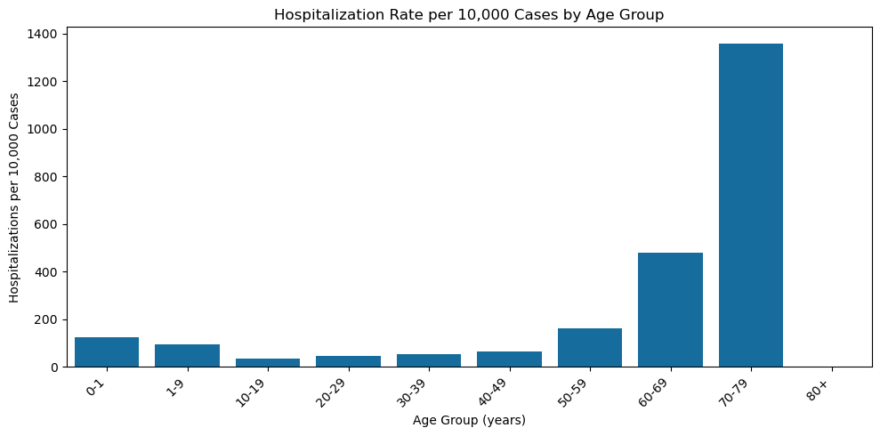

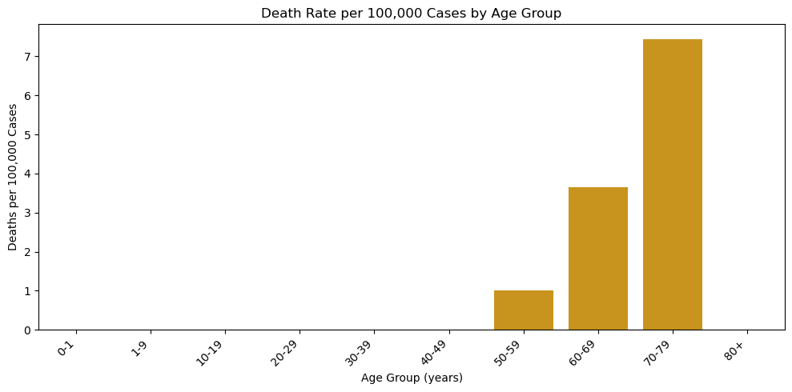

```
Highest hospitalization rate: 70-79 (1360.6 per 10,000 cases)
Highest death rate: 70-79 (7.4 per 100,000 cases)
```

```python
# Clean column names
cases_df.columns = cases_df.columns.str.strip()
hosp_df.columns = hosp_df.columns.str.strip()
death_df.columns = death_df.columns.str.strip()

# Ensure numeric case counts and ages
cases_df['Count'] = pd.to_numeric(cases_df['Count'], errors='coerce').fillna(0)
cases_df['Start Age (years)'] = pd.to_numeric(cases_df['Start Age (years)'], errors='coerce')
cases_df['End Age (years)']   = pd.to_numeric(cases_df['End Age (years)'], errors='coerce')

hosp_df['Hospitilizations'] = pd.to_numeric(hosp_df['Hospitilizations'], errors='coerce').fillna(0)
death_df['Deaths']          = pd.to_numeric(death_df['Deaths'], errors='coerce').fillna(0)

hosp_df['Start Age'] = pd.to_numeric(hosp_df['Start Age'], errors='coerce')
hosp_df['End Age']   = pd.to_numeric(hosp_df['End Age'], errors='coerce')
death_df['Start Age'] = pd.to_numeric(death_df['Start Age'], errors='coerce')
death_df['End Age']   = pd.to_numeric(death_df['End Age'], errors='coerce')

# Aggregate Age
age_bins = (
    hosp_df[['Start Age', 'End Age']]
    .drop_duplicates()
    .sort_values(['Start Age', 'End Age'])
    .reset_index(drop=True)
)

rows = []
for _, bin_row in age_bins.iterrows():
    bstart = bin_row['Start Age']
    bend   = bin_row['End Age']

    if np.isnan(bend):
        # open-ended bin, e.g. 80+
        mask = cases_df['Start Age (years)'] >= bstart
    else:
        # include all case age bands fully inside the bin
        mask = (
            (cases_df['Start Age (years)'] >= bstart) &
            (cases_df['End Age (years)']   <= bend)
        )

    bin_cases = cases_df.loc[mask, 'Count'].sum()
    rows.append({'Start Age': bstart, 'End Age': bend, 'Cases': bin_cases})

cases_binned = pd.DataFrame(rows)
cases_binned

# Aggregate hosp/ deaths
hosp_binned = (
    hosp_df.groupby(['Start Age','End Age'], as_index=False)['Hospitilizations']
           .sum()
)

death_binned = (
    death_df.groupby(['Start Age','End Age'], as_index=False)['Deaths']
            .sum()
)

severity_binned = (
    cases_binned
    .merge(hosp_binned, on=['Start Age','End Age'], how='left')
    .merge(death_binned, on=['Start Age','End Age'], how='left')
)

severity_binned[['Hospitilizations','Deaths']] = (
    severity_binned[['Hospitilizations','Deaths']].fillna(0)
)
severity_binned

# Severity Rates
severity_binned['HospRate_per10k']   = (
    severity_binned['Hospitilizations'] / severity_binned['Cases'] * 10000
)
severity_binned['DeathRate_per100k'] = (
    severity_binned['Deaths'] / severity_binned['Cases'] * 100000
)

## Age Bin
def format_age_bin(row):
    start = int(row['Start Age'])
    if np.isnan(row['End Age']):
        return f"{start}+"
    else:
        end = int(row['End Age'])
        return f"{start}-{end}"

severity_binned['AgeBin'] = severity_binned.apply(format_age_bin, axis=1)

severity_binned[['AgeBin','Cases','Hospitilizations','Deaths',
                 'HospRate_per10k','DeathRate_per100k']]

# Plot
severity_binned = severity_binned.sort_values('Start Age')

plt.figure(figsize=(10,5))
sns.barplot(data=severity_binned, x='AgeBin', y='HospRate_per10k', color='#0072B2')
plt.title('Hospitalization Rate per 10,000 Cases by Age Group')
plt.xlabel('Age Group (years)')
plt.ylabel('Hospitalizations per 10,000 Cases')
plt.xticks(rotation=45, ha='right')
plt.tight_layout()
plt.show()

plt.figure(figsize=(10,5))
sns.barplot(data=severity_binned, x='AgeBin', y='DeathRate_per100k', color='#E69F00')
plt.title('Death Rate per 100,000 Cases by Age Group')
plt.xlabel('Age Group (years)')
plt.ylabel('Deaths per 100,000 Cases')
plt.xticks(rotation=45, ha='right')
plt.tight_layout()
plt.show()

# Highest Risk
peak_hosp = severity_binned.loc[severity_binned['HospRate_per10k'].idxmax()]
peak_death = severity_binned.loc[severity_binned['DeathRate_per100k'].idxmax()]

print(
    f"Highest hospitalization rate: {peak_hosp['AgeBin']} "
    f"({peak_hosp['HospRate_per10k']:.1f} per 10,000 cases)"
)

print(
    f"Highest death rate: {peak_death['AgeBin']} "
    f"({peak_death['DeathRate_per100k']:.1f} per 100,000 cases)"
)
```

Although case counts during the 2024–2025 influenza season in Japan were extremely high, the hospitalization and death data show that severity was strongly age-dependent.

After aligning the fine-grained case age bands (e.g., 0–5 months, 1 year, 5–9 years) to the broader hospitalization bins (0–1, 1–9, 10–19, …, 80+), hospitalization rates rose steeply with age. Children aged 10-14 experienced the highest case volume, but older adults (especially 70–79 years) had the highest hospitalizations per 10,000 cases. Deaths were rare overall, but the death rate per 100,000 cases was concentrated in older age groups, consistent with typical influenza severity patterns.

These findings support the interpretation that the 2024–2025 season was concerning not because of unusually high lethality, but because of the enormous number of cases, particularly among children, combined with a concentrated burden of severe outcomes in older adults.

### Regional Comparison

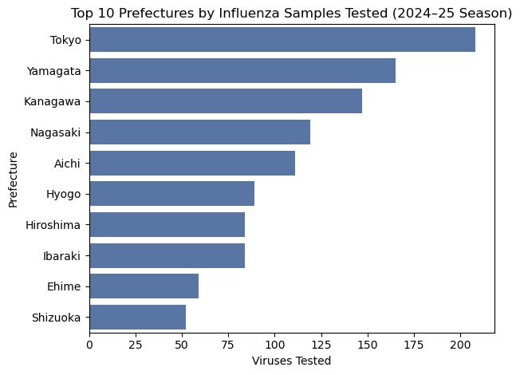

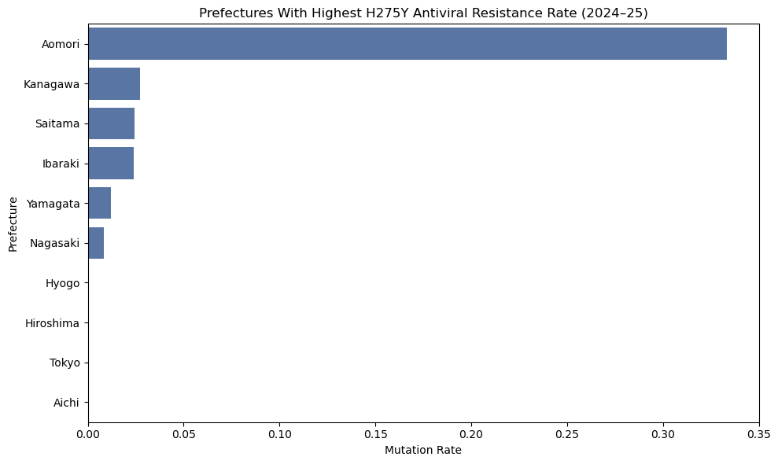

```python
# Clean columns
regional_df = dfs['Detection_H1N1_mH275Y_byp_2425'].copy()
regional_df.columns = regional_df.columns.str.strip()
regional_df.head()

# Antiviral Resistance Rate by Prefecture
regional_df['MutantRate'] = (
    regional_df['Number of H275Y Mutant Viruses'] /
    regional_df['Number of Viruses Tested']
)

regional_df['MixedRate'] = (
    regional_df['Number of 275H/Y Mixed Populations'] /
    regional_df['Number of Viruses Tested']
)

# Prefecture by sampling
regional_totals = (
    regional_df.groupby('Prefecture', as_index=False)
    .agg({
        'Number of Viruses Tested': 'sum',
        'Number of H275Y Mutant Viruses': 'sum',
        'Number of 275H/Y Mixed Populations': 'sum'
    })
    .sort_values('Number of Viruses Tested', ascending=False)
)

regional_totals.head(10)

# Top 10 Prefectures by viruses tested

top10 = regional_totals.head(10)

sns.barplot(
    data=top10,
    x='Number of Viruses Tested',
    y='Prefecture',
    color='#4C72B0'
)

plt.title("Top 10 Prefectures by Influenza Samples Tested (2024–25 Season)")
plt.xlabel("Viruses Tested")
plt.ylabel("Prefecture")
plt.tight_layout()
plt.show()

# Prefecture with highest antiviral rate
regional_totals['MutantRate'] = (
    regional_totals['Number of H275Y Mutant Viruses'] /
    regional_totals['Number of Viruses Tested']
)

regional_mutations = (
    regional_totals.sort_values('MutantRate', ascending=False)
    .head(10)
)

plt.figure(figsize=(10,6))

sns.barplot(
    data=regional_mutations,
    x='MutantRate',
    y='Prefecture',
    color='#4C72B0'
)

plt.title("Prefectures With Highest H275Y Antiviral Resistance Rate (2024–25)")
plt.xlabel("Mutation Rate")
plt.ylabel("Prefecture")
plt.tight_layout()
plt.show()
```

When examining antiviral resistance, Aomori displayed the highest H275Y mutation rate, standing out substantially compared to other prefectures. Kanagawa and Saitama also showed elevated resistance rates, suggesting that resistant strains may have emerged both in northern prefectures and within the Tokyo metropolitan area. These findings highlight the importance of regional surveillance to detect localized clusters of antiviral-resistant influenza strains.

### Rate of Change Analysis

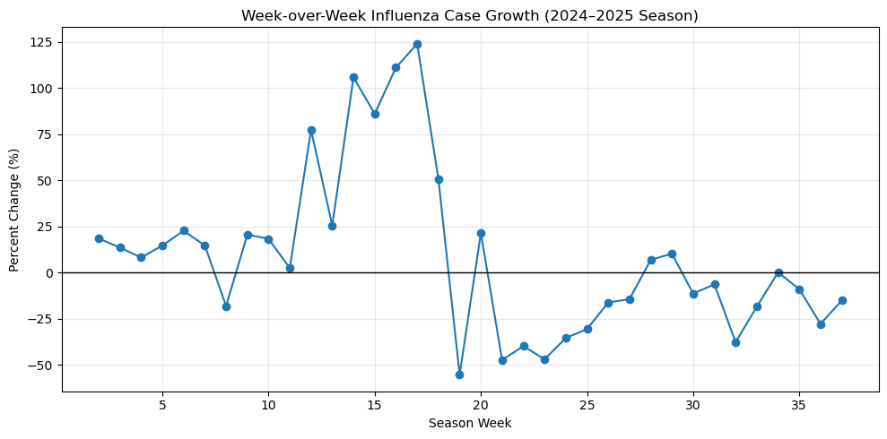

```
Fastest acceleration occurred in Season Week 17: 123.9% increase from previous week.
```

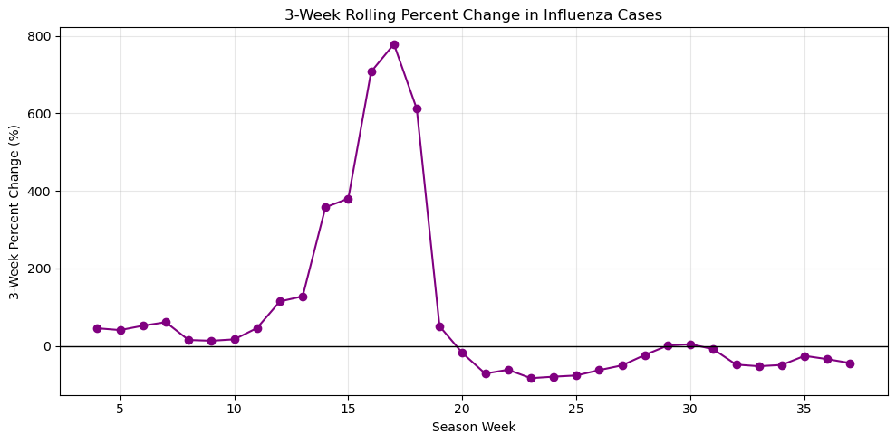

```python
# Week over week % change
season_trend['WoW_Change'] = season_trend['Count'].pct_change() * 100
season_trend.head()

# Rolling 3 week % change
season_trend['Roll_Change'] = (
    season_trend['Count']
    .pct_change(periods=3) * 100
)

# Plot week over week
plt.figure(figsize=(10,5))
plt.plot(season_trend['SeasonWeek'], season_trend['WoW_Change'], marker='o')
plt.axhline(0, color='black', linewidth=1)

plt.title("Week-over-Week Influenza Case Growth (2024–2025 Season)")
plt.xlabel("Season Week")
plt.ylabel("Percent Change (%)")
plt.grid(alpha=0.3)
plt.tight_layout()
plt.show()

# Max growth week
peak_growth = season_trend.loc[season_trend['WoW_Change'].idxmax()]
peak_growth

print(
    f"Fastest acceleration occurred in Season Week {int(peak_growth['SeasonWeek'])}: "
    f"{peak_growth['WoW_Change']:.1f}% increase from previous week."
)

# Rolling growth plot
plt.figure(figsize=(10,5))
plt.plot(season_trend['SeasonWeek'], season_trend['Roll_Change'], color='purple', marker='o')

plt.axhline(0, color='black', linewidth=1)
plt.title("3-Week Rolling Percent Change in Influenza Cases")
plt.xlabel("Season Week")
plt.ylabel("3-Week Percent Change (%)")
plt.grid(alpha=0.3)
plt.tight_layout()
plt.show()
```

### Forecasting Considerations

Although forecasting is often used in influenza surveillance, it was not included in this analysis because the full 2024–2025 season was already available. Forecasting known future values would not add useful insight and could be misleading. Instead, this project focuses on describing the season using summary statistics, growth-rate analysis, and regional comparisons to accurately reflect observed patterns.

## Insights

- The 2024–2025 influenza season in Japan showed a rapid early escalation, with case counts increasing sharply over a short period rather than building gradually.
- Rate-of-change analysis revealed that growth peaked quickly and transitioned into a sustained decline, indicating a relatively abrupt end to the season once transmission began to slow.
- Case burden varied meaningfully by age group and sex, with certain demographics contributing disproportionately to total reported cases.
  - 70-79 year olds were disproportionally effected by hospitilizations and deaths
  - 10-14 year olds dsiproportionally effected by a high volume of cases
- Regional surveillance intensity was uneven across prefectures, highlighting differences in testing volume that are important when interpreting geographic patterns.
- Antiviral resistance (H275Y) was rare and geographically limited, reinforcing that most regions recorded no detected mutations despite widespread testing.

## Conclusion

This project analyzed weekly influenza surveillance data from Japan to characterize the 2024–2025 influenza season. The analysis focused on descriptive statistics, seasonal alignment of weekly case counts, rate-of-change metrics, and regional comparisons to examine how the season evolved over time and across populations.

Antiviral resistance associated with the H275Y mutation was rare and geographically limited, with most prefectures recording no detected mutations despite widespread testing. This pattern underscores the importance of interpreting resistance data alongside testing volume rather than relying on raw rates alone.

Overall, this analysis demonstrates how influenza seasons can be effectively evaluated using simple, transparent methods that prioritize interpretability and data validity. By emphasizing observed trends, growth dynamics, and regional context, the project provides a clear retrospective summary of the 2024–2025 season and illustrates an approach that can support public health monitoring and post-season evaluation.